# Project: MediCal Eligibility Between Ethncities

## Data Description

The dataset titled “Race/Ethnicity of Eligible Individuals Under 21 Enrolled in Medi-Cal” provides information about racial and ethnic groups of Medi-Cal eligible individuals whose ages are under 21 in California. The racial and ethnic groups that the dataset categories includes Hispanics, White, Black, Asian (Chinese, Filipino, etc), Alaskan Natiive or American Indian, and Pacific Islanders. The data includes the reporting time period in year and month form, the categorize racial/ethnic group, and the number of eligible individuals for each group per year and month.

Reference:

[California Health and Human Services Open Data Portal. (n.d.). Race/Ethnicity of Eligible Individuals Under Age 21 Enrolled in Medi-Cal – Dataset.](https://data.chhs.ca.gov/dataset/eligible-individuals-under-age-21-enrolled-in-medi-cal-by-county/resource/c3bd3780-f419-4369-9f65-9b08cf54cb84)

## Data Cleaning

Data cleaning is an essential first step in preparing the dataset for visualizations. The process begins by loading all the used packages and the original dataset. Then, looking at the dataset, I realized that the names of each column are too long, so I first renamed the variables to shorter and simpler names. After renaming variables, I changed my column of the number of eligible individuals from a string to a numeric type to make sure the data is numeric. Next, I looked at the various ethnic groups in the ethnicity column. I changed one of the groups’ names into something more commonly used, such as turning Amerasian into Mixed Asian Americans. Finally, I separated my time into months and years, in case I needed to use separate analyses for the year and month. All of these changes to the original data create my base model for future datasets that I will make, like my dataset based on the total number of eligible individuals or based on 2024 data.

For the changes I made to get a dataset based on the total number of eligible individuals per year for each ethnic group, I used the clean base model that I created previously. First, I make sure the data is grouped by year and ethnic groups. After this simple arrangement, I turn the number of eligible individuals column into a total column by summarizing the sum of all eligible individuals who share the same ethnicity and year. These two changes create my yearly dataset comprising the year, the different ethnic groups, and the total number of eligible individuals per year for each ethnic group.

I also use the same clean base model for my changes to get the dataset based on recent data, aka the 2024 data. First, I arranged the data into just the year of 2024 by filtering the year section to 2024. Then, I arranged the data based on ethnicity and found the total sums of eligible individuals per ethnic group in the year 2024 by adding up all the monthly data into a new column. These changes created my dataset for 2024.

## Visualization 1

The visualization of the bar chart shows the top five and bottom five ethnic groups of eligible people under 21 in the Medi-Cal program in California over the past 12 years, from 2012 to 2024. The chart compares the total number of eligible individuals in each group, with the lights and longest bar indicating the ethnic groups with the most reports while the shortest and darkest bar being the group with the least amount of people.

This chart helps us understand the representation of people in the Medi-Cal system over time and shows what the general population is like over time. It gives insights into trends in healthcare access among different populations in California, while showing the trend of globalization and demographics in the US.

Something shocking in the visualization is that the ethnic category of Other and Not Reported is in the top 5. This result indicates that many Medi-Cal recipients choose not to record their ethnic identity, or the traditional racial categories do not fit them. This can highlight many things about the demographics of humans, as these two categories show potential gaps in data reporting or a shift into more multiracial populations in California and the Medi-Cal program over time. These findings help raise the question about how ethnicity is recorded and categorized, and suggest the need for more inclusive data collection.

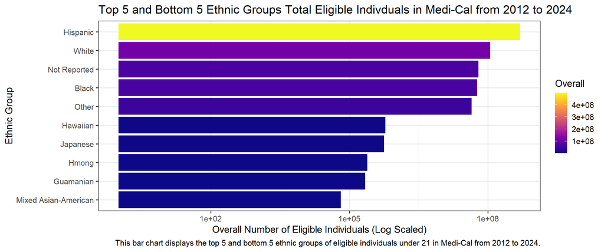

The given bar chart shows the top 5 and bottom 5 ethnic groups of eligible individuals under 21 in Medical from 2012 to 2024 (indicate top to bottom with highest at tip and lowest at the bottom). The chart compares the overall eligibility of different ethnic groups in the span of 12 years. The chart includes two categories, ‘Other’ and ‘Not Reported’, which represents individuals who do not fit into standard racial and ethnic categories and can be considered multiracial/underrepresented groups or does not disclose their information.

## Visualization 2

The line graph visualization illustrates the change in the total number of eligible individuals under 21 per year from 2012 to 2024 in the Medi-Cal program of California across the top 10 ethnic groups. Each line represents one ethnic group, which a unique combination of color and line type can distinguish. The number label at the end of each line helps recognize the corresponding ethnic group.

This visualization highlights the disparities and shifts in eligible individuals across ethnic groups over the years. It helps us see the patterns across the eligibility of each ethnic group and relate such patterns to the growing demographic and diversity in the US.

In the graph, we can see that there is an increase in Medi-Cal eligibility for almost all ethnic groups from 2012 to 2014. This can be because policies were added from 2012 to 2014 that supported low-income families and individuals to get Medi-Cal and transition children from one health program to Medi-Cal: reference to source [Medi-Cal Statistical Brief](https://www.dhcs.ca.gov/dataandstats/statistics/Documents/Historic-Growth-Brief.pdf). This shows how policies can affect the eligibility of individuals under 21 across many ethnic groups, which the graph visually explains.

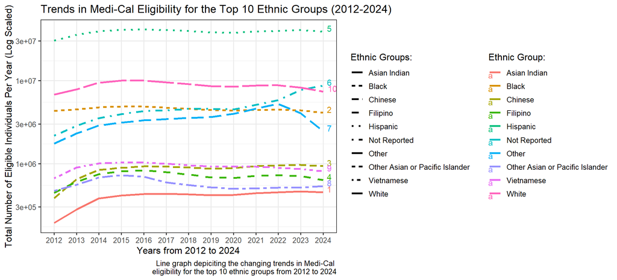

The given line graph portrays the trends in Medi-Cal eligibility for individuals under 21 whose in the top 10 ethnic groups from 2012 to 2024. The numbers on the each line associates with the name given in the alphabetical order of the ethnic group from top to bottom (from 1 to 10).

## Visualization 3

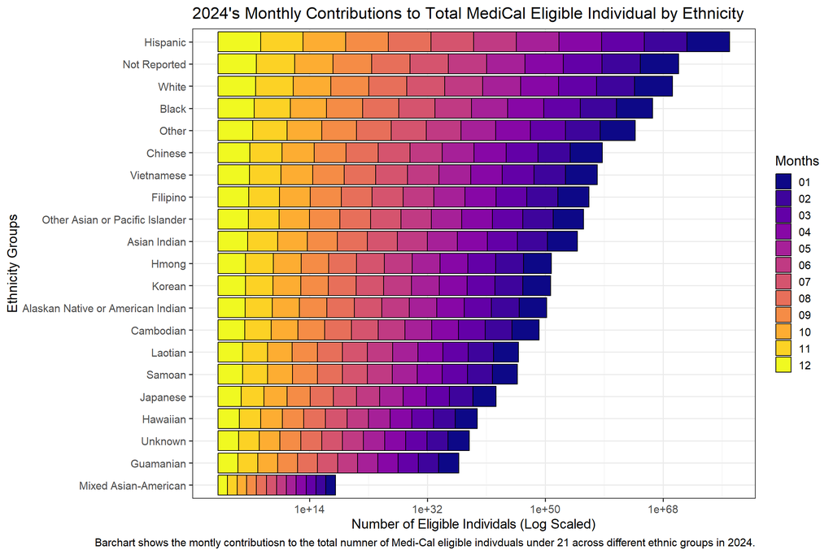